# Report Exercise Stepwise Regression

Timo Trinidad

2025-04-18

# Preparation:

```r
library(ggplot2)
library(readr)
library(lubridate)
library(dplyr)
library(patchwork)
library(here)
```

## Downloading the Data:

```r
url <- "https://raw.githubusercontent.com/geco-bern/agds_book/refs/heads/main/book/data/df_for_stepwise_regression.csv"

flux_data <- read.table(
  url,
  header = TRUE,
  sep = ","
)
```

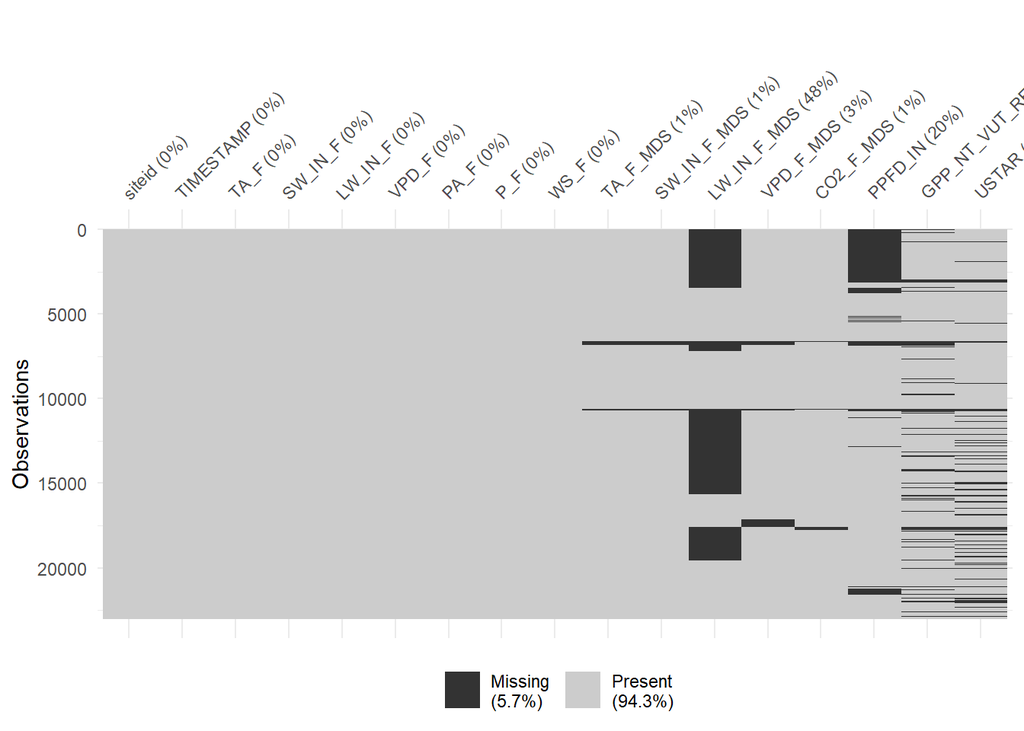

```r
visdat::vis_miss(
  flux_data,
  cluster = FALSE,
  warn_large_data = FALSE
  )
```

- In the course of a first look on the datatable I noticed that the gapfilled longwave radiation (LW_IN_F_MDS) seems to have quite some missing values. This is backed by the code in the following line, which shows it only contains 11954 non-missing values. As the following regression models demands equal numbers of observations over all included variables, including LW_IN_F_MDS would ineviteably imply losing almost half of all observations over all included variables. Based on this concern and drawing on the fact that the incoming longwave radiation is also covered by LW_IN_F, I decide to leave LW_IN_F_MDS out of the vector of the model variables. Besides that I’m also not considering siteid (obviously) and TIMESTEP (as we have the most physical variables causally linked to GPP and varying over time included, I assume in the end the effect of a time variable will be very small/insignificant).

This selection yields a sample of n= 15442 observations (which are ~67% of the initial sample), when including all 14 variables.

```r
## Model Variable selection:
head(flux_data)
```

```
##   siteid  TIMESTAMP   TA_F SW_IN_F LW_IN_F VPD_F   PA_F P_F  WS_F TA_F_MDS
## 1 CH-Dav 1997-01-01 -4.570  77.421 222.863 0.565 82.623 0.4 0.559   -4.570
## 2 CH-Dav 1997-01-02 -3.336  45.588 234.840 0.978 82.883 0.0 1.107   -3.336
## 3 CH-Dav 1997-01-03  0.278  74.069 238.729 2.243 82.398 0.0 2.030    0.278
## 4 CH-Dav 1997-01-04 -1.876  58.069 249.899 1.381 81.697 1.8 1.918   -1.876
## 5 CH-Dav 1997-01-05 -4.955  80.798 247.938 1.155 82.263 0.0 0.407   -4.955
## 6 CH-Dav 1997-01-06 -4.484  59.552 236.668 0.838 82.724 0.0 0.466   -4.484
##   SW_IN_F_MDS LW_IN_F_MDS VPD_F_MDS CO2_F_MDS PPFD_IN GPP_NT_VUT_REF     USTAR
## 1      77.421          NA     0.565   359.983      NA             NA 0.1425292
## 2      45.588          NA     0.978   361.031      NA             NA 0.1736813
## 3      74.069          NA     2.243   355.476      NA     -0.2422790 0.3654438
## 4      58.069          NA     1.381   355.998      NA      0.2466350 0.2926745
## 5      80.798          NA     1.155   360.736      NA      0.5195420 0.1214729
## 6      59.552          NA     0.838   364.353      NA      0.0182312 0.1191312
```

```r
sum(!is.na(flux_data$LW_IN_F_MDS))
```

```
## [1] 11954
```

```r
dim(na.omit(flux_data[,-c(1,2,12)]))
```

```
## [1] 15442    14
```

```r
vars <- flux_data[,-c(1,2,12)]
vars <- vars[,c(13,1:12,14)] #rearranging columns

# I'm storing the cleaned data:
write.csv(flux_data, here("re_stepwise/data/df_for_stepwise_regression_clean.csv"))
```

```r
caret::nearZeroVar(vars, saveMetrics = TRUE)
```

```
##                freqRatio percentUnique zeroVar   nzv
## GPP_NT_VUT_REF  1.000000      88.85750   FALSE FALSE
## TA_F            1.000000      71.55708   FALSE FALSE
## SW_IN_F         1.000000      96.06710   FALSE FALSE
## LW_IN_F         1.000000      93.42054   FALSE FALSE
## VPD_F           6.500000      39.48546   FALSE FALSE
## PA_F            1.062500      37.33866   FALSE FALSE
## P_F            14.865535      15.88805   FALSE FALSE
## WS_F            1.000000      21.88519   FALSE FALSE
## TA_F_MDS        1.000000      70.26639   FALSE FALSE
## SW_IN_F_MDS     1.000000      93.60306   FALSE FALSE
## VPD_F_MDS       2.418605      39.02481   FALSE FALSE
## CO2_F_MDS       1.000000      82.30846   FALSE FALSE
## PPFD_IN         1.000000      79.97479   FALSE FALSE
## USTAR           1.000000      87.94924   FALSE FALSE
```

Why am I am keeping for some variables both metrics (e.g.TA_F_MDS and TA_F)? Having almost identical predictors included in the model is a good test for the following “algorithm”: As they are very equal, after having included one of them, the other should add (alomost) no additional variance, therefore not enhancing the R^2, so not/only at the very end, beeing included.

Checking the distribution of the target variable:

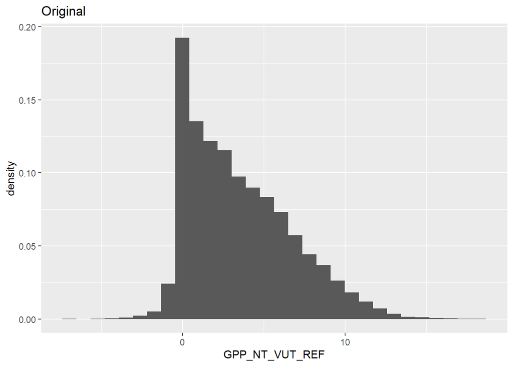

```r
plot_1 <- ggplot(data = vars, aes(x = GPP_NT_VUT_REF, y = ..density..)) +
  geom_histogram() +
  labs(title = "Original")
plot_1
```

# Exercise 1: ## Univariate Models:

```r
plot_vec <- list()
metrics <- c()

for (i in 2:length(vars)) {
  mod_1 <- lm(vars[,1] ~ vars[,i], na.action = na.omit)
  mod_sum <- summary(mod_1)

  metrics["R^2"] <- mod_sum$r.squared
  metrics["RMSE"] <- sqrt(mean(mod_sum$residuals^2))
  metrics["Bias"] <- mean(mod_sum$residuals)
  metrics["Slope"] <- mod_sum$coefficients[2,1]

  df_plot <- data.frame(
    Y = vars[as.numeric(rownames(mod_1$model)),1],
    Y_hat = mod_1$fitted.values
  )

  plot_vec[[i-1]] <- ggplot(df_plot, aes(x = Y_hat, y = Y)) +
    geom_point(alpha = 0.1) +
    labs(
      x = expression(hat(Y)),
      y = "Y",
      title = colnames(vars)[i],
      subtitle = paste(paste(names(metrics), round(metrics, 3), sep = " = "), collapse = ", ")
    ) +
    geom_abline(intercept = 0, slope = 1, linetype = "dashed", color = "darkgreen") +
    geom_abline(intercept = mod_sum$coefficients[1,1], slope = mod_sum$coefficients[2,1], color = "red") +
    coord_cartesian(xlim = c(-5,15), ylim = c(-5,15)) +
    theme_classic() +
    theme(plot.subtitle = element_text(size = 7))
}
```

## Visualisation:

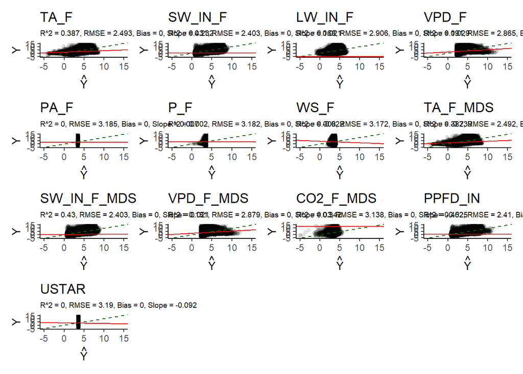

```r
wrap_plots(plot_vec, ncol = 4)
```

## Interpretation:

For analysing my results I refer to the following equation: GPP = PPFD * fAPAR * LUE, where PPFD measures the solar radiation (photon) flux, fAPAR denotes the fraction of absorbed potosynthetically active radiation and LUE stands for the Light use efficency describing the efficency with which absorbed photons are used to convert atmospheric C02 into C in the form of sugars.

Hypothesis: I expect the highest R^2 values for variables, which depict one of the components of the equation above - directly or as (highly correlated) proxis. For variables, which do not have a (strong) connection to one of the equation’s componenents I expect small values for R^2.

Results: As expected, the highest R^2 value of 0.452 is achieved by the incoming photosynthetic photon flux density (PPFD_IN), a variable that is directly represented in the equation explaining GPP. Next, the incoming shortwave radiation (SW_IN_F/SW_IN_F_MDS) explains 43% of the variance in GPP values. I explain its relatively high R^2 value by the fact that it is strongly correlated with PPFD. This can be verified by performing a bivariate regression with both explanatory variables. I expect that the coefficient of shortwave radiation will no longer be significant, as the omitted variable bias that existed in the univariate regression with regard to photon flux density will now disappear.

```r
summary(lm(GPP_NT_VUT_REF ~ PPFD_IN + SW_IN_F ,data = vars, na.action = na.omit))
```

```
##
## Call:
## lm(formula = GPP_NT_VUT_REF ~ PPFD_IN + SW_IN_F, data = vars,
##     na.action = na.omit)
##
## Residuals:
##     Min      1Q  Median      3Q     Max
## -8.0712 -1.3249 -0.3742  1.2780 12.3286
##
## Coefficients:
##               Estimate Std. Error t value Pr(>|t|)
## (Intercept)  0.7259705  0.0309040  23.491   <2e-16 ***
## PPFD_IN      0.0107010  0.0005900  18.137   <2e-16 ***
## SW_IN_F     -0.0001721  0.0012105  -0.142    0.887
## ---
## Signif. codes:  0 '***' 0.001 '**' 0.01 '*' 0.05 '.' 0.1 ' ' 1
##
## Residual standard error: 2.41 on 16871 degrees of freedom
##   (6137 Beobachtungen als fehlend gelöscht)
## Multiple R-squared:  0.4521, Adjusted R-squared:  0.452
## F-statistic:  6960 on 2 and 16871 DF,  p-value: < 2.2e-16
```

With regard to the other variables – precipitation (P_F), wind speed (WS_F), atmospheric pressure (PA_F), friction velocity (USTAR) – these have a value of R^2 < 0.1, thus hardly explaining the variance in the GPP data. Although these variables can be combined with the factors in the above equation, but the correlation is very low/indirect (e.g. precipitation is related to atmospheric moisture content, which in turn affects the water vapour pressure gradient between the leaf surface and the leaf interior, which is one of the factors that regulates stomatal opening, which affects LUE).

Finally, all R^2 values are probably suppressed by the low variance in the GPP values (sd = 3.2): the smaller the variance in the values of the dependent variable, the more difficult it is to map them significantly by the variance of another variable.

# Exercise 2:

## Model Algorith:

```r
mod_pred <- c(colnames(vars)[1])
R_max = 0
AIC_old = -1

  for (j in 2:(ncol(vars))) {
    p = 0
    for (i in 2:ncol(vars)) {
      mod_pred[j] <- colnames(vars)[i]
      if (length(mod_pred) < 3) {
       mod_2 <- lm(as.formula(paste(mod_pred, collapse = "~")), data = vars)
      } else {
      mod_2 <- lm(as.formula(paste(mod_pred[1], "~",paste(mod_pred[-1], collapse ="+"))), data = vars, na.action =  na.omit) }
      R <- summary(mod_2)$r.squared
      if (R > R_max) {
        R_max <- R
        p <- i
      }

      AIC = nrow(vars)* log(sum(mod_2$residuals^2)/nrow(vars)) + 2*(length(mod_pred) + 1) # just "+1 as mod_pred also includes dependent variable.
    }
    mod_pred[j] <- colnames(vars)[p]
    if (AIC > AIC_old & AIC_old >0) {
      mod_pred <- mod_pred[-length(mod_pred)]
      break
    } else {
      AIC_old <- AIC
    }
  }

mod_fin<- lm(paste(mod_pred[1], " ~ ", paste(mod_pred[-1], collapse = " + ")), data = vars)
summary(mod_fin)
```

```
##
## Call:
## lm(formula = paste(mod_pred[1], " ~ ", paste(mod_pred[-1], collapse = " + ")),
##     data = vars)
##
## Residuals:
##     Min      1Q  Median      3Q     Max
## -7.7483 -1.2228 -0.1155  1.1091 12.3241
##
## Coefficients:
##               Estimate Std. Error t value Pr(>|t|)
## (Intercept) -1.5918166  0.4463214  -3.567 0.000363 ***
## PPFD_IN      0.0067220  0.0005163  13.020  < 2e-16 ***
## LW_IN_F      0.0152710  0.0006863  22.250  < 2e-16 ***
## VPD_F       -0.3884717  0.0077778 -49.946  < 2e-16 ***
## TA_F_MDS     0.1781049  0.0958642   1.858 0.063202 .
## SW_IN_F      0.0127878  0.0010751  11.895  < 2e-16 ***
## P_F         -0.0233879  0.0026830  -8.717  < 2e-16 ***
## WS_F        -0.1375588  0.0138286  -9.947  < 2e-16 ***
## CO2_F_MDS   -0.0064401  0.0007676  -8.390  < 2e-16 ***
## PA_F         0.0076826  0.0032007   2.400 0.016394 *
## TA_F        -0.0747595  0.0959772  -0.779 0.436032
## ---
## Signif. codes:  0 '***' 0.001 '**' 0.01 '*' 0.05 '.' 0.1 ' ' 1
##
## Residual standard error: 2.064 on 16863 degrees of freedom
##   (6137 Beobachtungen als fehlend gelöscht)
## Multiple R-squared:  0.5983, Adjusted R-squared:  0.598
## F-statistic:  2511 on 10 and 16863 DF,  p-value: < 2.2e-16
```

## Visualisation:

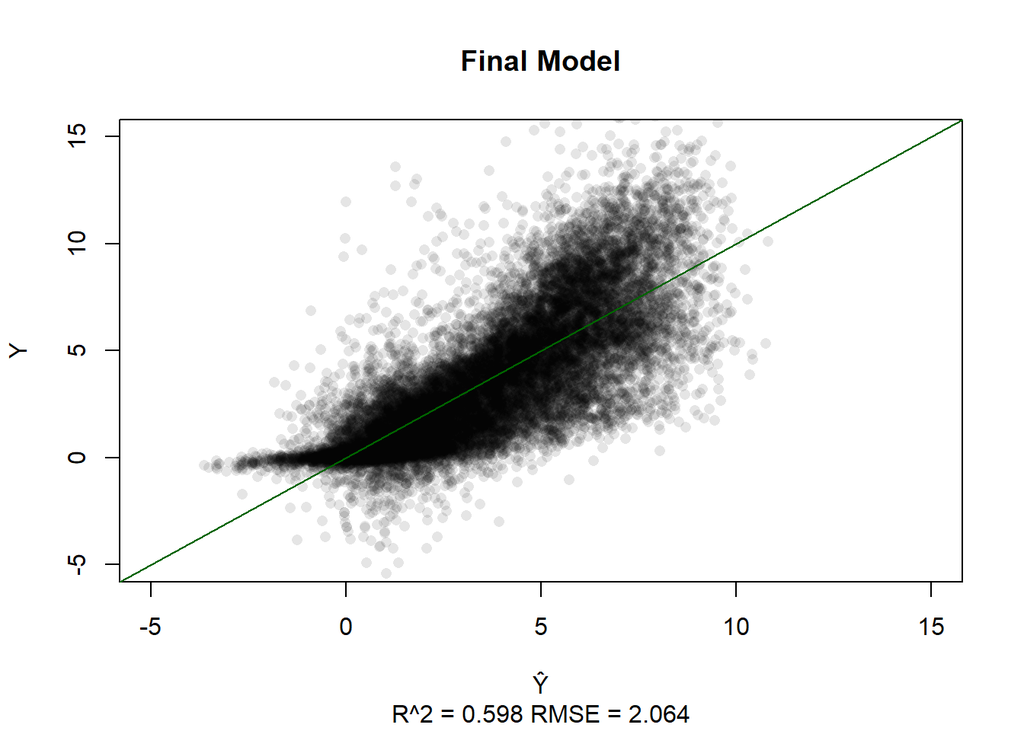

```r
plot(x = mod_fin$fitted.values , y = vars[as.numeric(rownames(mod_fin$model)),1], xlim = c(-5,15), ylim = c(-5,15), main = "Final Model", sub = paste(paste("R^2 =", round(summary(mod_fin)$r.squared, digits = 3)), paste("RMSE =", round(sqrt(mean(summary(mod_fin)$residuals^2)), digits = 3)), collapse = ", "), xlab = "Ŷ", ylab = "Y", col = rgb(0,0,0, alpha = 0.1), pch = 16)
abline(a= 0, b=1, col = "darkgreen")
```

## Interpretation:

I got the following model:

```r
paste(mod_pred[1], " ~ ", paste(mod_pred[-1], collapse = " + "))
```

```
## [1] "GPP_NT_VUT_REF  ~  PPFD_IN + LW_IN_F + VPD_F + TA_F_MDS + SW_IN_F + P_F + WS_F + CO2_F_MDS + PA_F + TA_F"
```

My analysis is again based on the equation given in exercise 1. After PPFD, which achieved the highest R^2 value in the univariate regression, the long-wave radiation variable was added to the bivariate regression. This is interesting because the univariate regression with the long-wave radiation variable only had a low R^2 value of 0.17. Conversely, this could mean that variables that yielded higher R^2 values in the univariate regression – shortwave radiation, air temperature – correlate strongly with PPFD, so that they contribute little ‘new variance’ to the model. (With regard to the influence of temperature, this would support my alternative explanatory approach from above, namely that it correlates with GPP because it also correlates with solar radiation.) The third explanatory variable is the vapour pressure deficit, followed by air temperature and shortwave radiation.